# Julia_Moffitt_Final_Version_DL_For_Malaria_Detection

# **Model 3: ReLU, BatchNormalization**

- ReLU: To make deep layers learn quicker.
- Batch Normalization: To allow each layer to be standarized and learn independently, which should help learn faster.
- Increase batch size slightly to also increase speed.

```python
#Clearing backend
from tensorflow.keras import backend
from keras.regularizers import l2
backend.clear_session()

#Fixing the seed for random number generators
np.random.seed(42)
import random
random.seed(42)
tf.random.set_seed(42)
```

```python
def CNNbuild3(height, width, classes, channels):
    model = Sequential()

    inputShape = (height, width, channels)
    chanDim = -1

    if K.image_data_format() == 'channels_first':
        inputShape = (channels, height, width)
    model.add(Conv2D(32, (3,3), activation = 'relu', input_shape = inputShape))
    model.add(MaxPooling2D(2,2))
    model.add(BatchNormalization(axis = chanDim))
    model.add(Dropout(0.2))

    model.add(Conv2D(64, (3,3), activation = 'relu'))
    model.add(MaxPooling2D(2,2))
    model.add(BatchNormalization(axis = chanDim))
    model.add(Dropout(0.2))

    #model.add(Conv2D(32, (3,3), activation = 'relu'))
    #model.add(MaxPooling2D(2,2))
    #model.add(BatchNormalization(axis = chanDim))
    #model.add(Dropout(0.2))

    model.add(Flatten())

    model.add(Dense(256, activation = 'relu'))
    model.add(BatchNormalization(axis = chanDim))
    model.add(Dropout(0.5))
    model.add(Dense(classes, activation = 'softmax'))

    return model
```

```python
#instantiate the model
height = 64
width = 64
classes = 2
channels = 3
model3 = CNNbuild3(height = height, width = width, classes = classes, channels = channels)
model3.summary()
```

```
Model: "sequential"
_________________________________________________________________
 Layer (type)                Output Shape              Param #
=================================================================
 conv2d (Conv2D)             (None, 62, 62, 32)        896

 max_pooling2d (MaxPooling2D  (None, 31, 31, 32)       0
 )

 batch_normalization (BatchN  (None, 31, 31, 32)       128
 ormalization)

 dropout (Dropout)           (None, 31, 31, 32)        0

 conv2d_1 (Conv2D)           (None, 29, 29, 64)        18496

 max_pooling2d_1 (MaxPooling  (None, 14, 14, 64)       0
 2D)

 batch_normalization_1 (Batc  (None, 14, 14, 64)       256
 hNormalization)

 dropout_1 (Dropout)         (None, 14, 14, 64)        0

 flatten (Flatten)           (None, 12544)             0

 dense (Dense)               (None, 256)               3211520

 batch_normalization_2 (Batc  (None, 256)              1024
 hNormalization)

 dropout_2 (Dropout)         (None, 256)               0

 dense_1 (Dense)             (None, 2)                 514

=================================================================
Total params: 3,232,834
Trainable params: 3,232,130
Non-trainable params: 704
_________________________________________________________________
```

```python
#compile the model
#tf.keras.optimizers.SGD(learning_rate=0.001, momentum=0.9, nesterov=False, name="SGD")
model3.compile(optimizer='Adam', loss='binary_crossentropy', metrics=['accuracy'])
```

```python
experiment_name = "base_CNN+ReLU+BatchNormalization"
logdir = os.path.join(base_logdir, experiment_name)
tensorboard_callback = tf.keras.callbacks.TensorBoard(logdir, histogram_freq=1)
```

```python
#using callbacks
callbacks = [EarlyStopping(monitor='val_loss', patience=3),
             ModelCheckpoint('.mdl_wts.hdf5', monitor='val_loss', save_best_only=True), tensorboard_callback]
```

```python
#Fit the model with min batch size as 32 can tune batch size to some factor of 2^power ]
history3=model3.fit(x_train,y_train,batch_size=32,callbacks=callbacks,validation_split=0.2,epochs=20,verbose=1)
```

**Plotting the train and validation curves**

**Plotting the confusion matrix**

```python
# function to plot train and validation accuracy
def plot_accuracy(history3):
    N = len(history3.history["accuracy"])
    plt.figure(figsize=(7,7))
    plt.plot(np.arange(0, N), history3.history["accuracy"], label="train_accuracy", ls='--')
    plt.plot(np.arange(0, N), history3.history["val_accuracy"], label="val_accuracy", ls='--')
    plt.plot(np.arange(0, N), history3.history["loss"], label="val_loss", ls='--')
    plt.title("Accuracy vs Epoch")
    plt.xlabel("Epochs")
    plt.ylabel("Accuracy")
    plt.legend(loc="upper left")
```

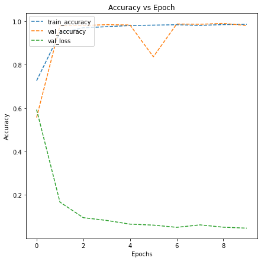

```python
plot_accuracy(history3)
```

```python
accuracy = model3.evaluate(x_test, y_test, verbose=1)
print('\n', 'Test_Accuracy:-', accuracy[1])
```

```
 Test_Accuracy:- 0.9749665856361389
```

```
              precision    recall  f1-score   support

           0       0.95      1.00      0.97      2535
           1       1.00      0.95      0.98      2698

    accuracy                           0.97      5233
   macro avg       0.98      0.98      0.97      5233
weighted avg       0.98      0.97      0.97      5233
```

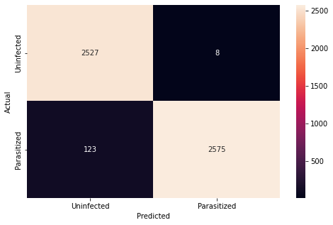

```python
from sklearn.metrics import classification_report
from sklearn.metrics import confusion_matrix

pred = model3.predict(x_test)
pred = np.argmax(pred,axis = 1)
y_true = np.argmax(y_test,axis = 1)

#Printing the classification report
print(classification_report(y_true,pred))

#Plotting the heatmap using confusion matrix
cm = confusion_matrix(y_true,pred)
plt.figure(figsize=(8,5))
sns.heatmap(cm, annot=True,  fmt='.0f', xticklabels=['Uninfected', 'Parasitized'], yticklabels=['Uninfected', 'Parasitized'])
plt.ylabel('Actual')
plt.xlabel('Predicted')
plt.show()
```

**Observations and Insights**

- The performance of the model increased substantially by making the modifications.
- The model fit much more quickly (30s vs. 2 minutes), and is more computationally efficient. This is likely due to the use of ReLU as an activation function and use of Batch Normalization in deep layers.
- The overall accuracy of Model 3 improved to 97% versus 96% in Model 2, while the number of false negatives decreased, leading to an improvement in recall and precision.
- We would like to reduce the number of false negatives and increase recall for parasitized even further.

# **Model 4: Adding additional Layer**

- In this iteration we will try to increase the performace even more to reduce false negative rate by adding an additional layer.
- To mitigate overfitting dropout rate will be increased from 0.2 to 0.3 and added to the additional layer.

```python
#Clearing backend
from tensorflow.keras import backend
from keras.regularizers import l2
backend.clear_session()

#Fixing the seed for random number generators
np.random.seed(42)
import random
random.seed(42)
tf.random.set_seed(42)
```

```python
# Build model4 with increased dropout
def CNNbuild4(height, width, classes, channels):
    model = Sequential()

    inputShape = (height, width, channels)
    chanDim = -1

    if K.image_data_format() == 'channels_first':
        inputShape = (channels, height, width)
    model.add(Conv2D(32, (3,3), activation = 'relu', input_shape = inputShape))
    model.add(MaxPooling2D(2,2))
    model.add(BatchNormalization(axis = chanDim))
    model.add(Dropout(0.3))

    model.add(Conv2D(32, (3,3), activation = 'relu'))
    model.add(MaxPooling2D(2,2))
    model.add(BatchNormalization(axis = chanDim))
    model.add(Dropout(0.3))

    model.add(Conv2D(32, (3,3), activation = 'relu'))
    model.add(MaxPooling2D(2,2))
    model.add(BatchNormalization(axis = chanDim))
    model.add(Dropout(0.3))

    model.add(Flatten())

    model.add(Dense(512, activation = 'relu'))
    model.add(BatchNormalization(axis = chanDim))
    model.add(Dropout(0.5))
    model.add(Dense(classes, activation = 'softmax'))

    return model
```

```python
#instantiate the model
height = 64
width = 64
classes = 2
channels = 3
model4 = CNNbuild4(height = height, width = width, classes = classes, channels = channels)
model4.summary()
```

```
Model: "sequential"
_________________________________________________________________
 Layer (type)                Output Shape              Param #
=================================================================
 conv2d (Conv2D)             (None, 62, 62, 32)        896

 max_pooling2d (MaxPooling2D  (None, 31, 31, 32)       0
 )

 batch_normalization (BatchN  (None, 31, 31, 32)       128
 ormalization)

 dropout (Dropout)           (None, 31, 31, 32)        0

 conv2d_1 (Conv2D)           (None, 29, 29, 32)        9248

 max_pooling2d_1 (MaxPooling  (None, 14, 14, 32)       0
 2D)

 batch_normalization_1 (Batc  (None, 14, 14, 32)       128
 hNormalization)

 dropout_1 (Dropout)         (None, 14, 14, 32)        0

 conv2d_2 (Conv2D)           (None, 12, 12, 32)        9248

 max_pooling2d_2 (MaxPooling  (None, 6, 6, 32)         0
 2D)

 batch_normalization_2 (Batc  (None, 6, 6, 32)         128
 hNormalization)

 dropout_2 (Dropout)         (None, 6, 6, 32)          0

 flatten (Flatten)           (None, 1152)              0

 dense (Dense)               (None, 512)               590336

 batch_normalization_3 (Batc  (None, 512)              2048
 hNormalization)

 dropout_3 (Dropout)         (None, 512)               0

 dense_1 (Dense)             (None, 2)                 1026

=================================================================
Total params: 613,186
Trainable params: 611,970
Non-trainable params: 1,216
_________________________________________________________________
```

```python
#compile the model
model4.compile(optimizer='adam', loss='binary_crossentropy', metrics=['accuracy'])
```

```python
experiment_name = "base_CNN+ReLU+BatchNormalization+add_layer"
logdir = os.path.join(base_logdir, experiment_name)
tensorboard_callback = tf.keras.callbacks.TensorBoard(logdir, histogram_freq=1)
```

```python
#using callbacks
callbacks = [EarlyStopping(monitor='val_loss', patience=3),
             ModelCheckpoint('.mdl_wts.hdf5', monitor='val_loss', save_best_only=True),tensorboard_callback]
```

**Fit and Train the model**

```python
#Fit the model with min batch size as 32 can tune batch size to some factor of 2^power ]
history4=model4.fit(x_train,y_train,batch_size=32,callbacks=callbacks,validation_split=0.2,epochs=20,verbose=1)
```

#### **Evaluating the Model 4**

**Plot the train and validation accuracy**

```python
# function to plot train and validation accuracy
def plot_accuracy(history4):
    N = len(history4.history["accuracy"])
    plt.figure(figsize=(7,7))
    plt.plot(np.arange(0, N), history4.history["accuracy"], label="train_accuracy", ls='--')
    plt.plot(np.arange(0, N), history4.history["val_accuracy"], label="val_accuracy", ls='--')
    plt.plot(np.arange(0, N), history4.history["loss"], label="train_loss", ls='--')
    plt.title("Accuracy vs Epoch")
    plt.xlabel("Epochs")
    plt.ylabel("Accuracy")
    plt.legend(loc="upper left")
```

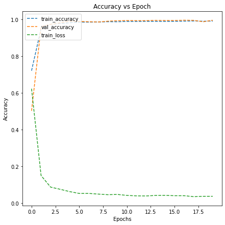

```python
# plotting the accuracies and loss
plot_accuracy(history4)
```

**Plotting the classification report and confusion matrix**

```python
#test accuracy calculation
accuracy = model4.evaluate(x_test, y_test, verbose=1)
print('\n', 'Test_Accuracy:-', accuracy[1])
```

```
 Test_Accuracy:- 0.9919739961624146
```

```
              precision    recall  f1-score   support

           0       0.99      0.99      0.99      2535
           1       0.99      0.99      0.99      2698

    accuracy                           0.99      5233
   macro avg       0.99      0.99      0.99      5233
weighted avg       0.99      0.99      0.99      5233
```

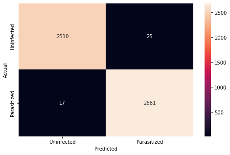

```python
from sklearn.metrics import classification_report
from sklearn.metrics import confusion_matrix

pred = model4.predict(x_test)
pred = np.argmax(pred,axis = 1)
y_true = np.argmax(y_test,axis = 1)

#Printing the classification report
print(classification_report(y_true,pred))

#Plotting the heatmap using confusion matrix
cm = confusion_matrix(y_true,pred)
plt.figure(figsize=(8,5))
sns.heatmap(cm, annot=True,  fmt='.0f', xticklabels=['Uninfected', 'Parasitized'], yticklabels=['Uninfected', 'Parasitized'])
plt.ylabel('Actual')
plt.xlabel('Predicted')
plt.show()
```

**Model 4 Observations & Insights:**

- The performance on this model was excellent at 99% recall, 99% precision and 99% accuracy.
- In addition, the number of false negatives was very low at only 17 incorrectly identified images out of 5233. This is an important metric with training a medical diagnostic model.
- Increasing the number of layers and complexity increased the performance. Accordingly increasing the dropout rate slightly helped prevent overfitting.
- The speed of the model was still quite good and fit within 1 minute.

# **Model 5: HSV Image Augmentation**

### **Converting RGB to HSV of Images using OpenCV**

#### **Converting the train data**

```python
import cv2
gfx=[]   # to hold the HSV image array
for i in np.arange(0,20928,1):
  a=cv2.cvtColor(x_train[i],cv2.COLOR_BGR2HSV)
  gfx.append(a)
gfx=np.array(gfx)
```

```
Clipping input data to the valid range for imshow with RGB data ([0..1] for floats or [0..255] for integers).
Clipping input data to the valid range for imshow with RGB data ([0..1] for floats or [0..255] for integers).
Clipping input data to the valid range for imshow with RGB data ([0..1] for floats or [0..255] for integers).
Clipping input data to the valid range for imshow with RGB data ([0..1] for floats or [0..255] for integers).
Clipping input data to the valid range for imshow with RGB data ([0..1] for floats or [0..255] for integers).
```

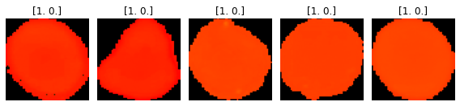

```python
viewimage=np.random.randint(1,20928,5)
fig,ax=plt.subplots(1,5,figsize=(8,8))
for t,i in zip(range(5),viewimage):
  Title=y_train[i]
  ax[t].set_title(Title)
  ax[t].imshow(gfx[i])
  ax[t].set_axis_off()
  fig.tight_layout()
```

#### **Converting the test data**

```python
# Visualizing images in the test data

gfx2=[]   # to hold the HSV image array
for i in np.arange(0,5233,1):
  a=cv2.cvtColor(x_test[i],cv2.COLOR_BGR2HSV)
  gfx2.append(a)
gfx2=np.array(gfx2)
```

```
Clipping input data to the valid range for imshow with RGB data ([0..1] for floats or [0..255] for integers).
Clipping input data to the valid range for imshow with RGB data ([0..1] for floats or [0..255] for integers).
Clipping input data to the valid range for imshow with RGB data ([0..1] for floats or [0..255] for integers).
Clipping input data to the valid range for imshow with RGB data ([0..1] for floats or [0..255] for integers).
Clipping input data to the valid range for imshow with RGB data ([0..1] for floats or [0..255] for integers).
```

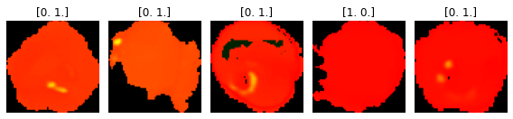

```python
viewimage=np.random.randint(1,5233,5)
fig,ax=plt.subplots(1,5,figsize=(8,8))
for t,i in zip(range(5),viewimage):
  Title=y_test[i]
  ax[t].set_title(Title)
  ax[t].imshow(gfx2[i])
  ax[t].set_axis_off()
  fig.tight_layout()
```

```python
print(f'SHAPE OF TRAINING HSV IMAGE DATA : {gfx.shape}')
print(f'SHAPE OF TESTING IMAGE DATA : {gfx2.shape}')
```

```
SHAPE OF TRAINING HSV IMAGE DATA : (20928, 64, 64, 3)
SHAPE OF TESTING IMAGE DATA : (5233, 64, 64, 3)
```

##### **Observations:**

We can see with the change to HSV the images show a contrast and the plasmodium shows up as light spots in the infected images.

```python
#Clearing backend
from tensorflow.keras import backend
backend.clear_session()
#Fixing the seed for random number generators
np.random.seed(42)
import random
random.seed(42)
tf.random.set_seed(42)
```

#### **Building Model 5: HSV Augmentation w/ Model4 - best performer**

```python
#instantiate the model calling the build for Model 4 which had the best performance.
height = 64
width = 64
classes = 2
channels = 3
model5 = CNNbuild4(height = height, width = width, classes = classes, channels = channels)
model5.summary()
```

```
Model: "sequential"
_________________________________________________________________
 Layer (type)                Output Shape              Param #
=================================================================
 conv2d (Conv2D)             (None, 62, 62, 32)        896

 max_pooling2d (MaxPooling2D  (None, 31, 31, 32)       0
 )

 batch_normalization (BatchN  (None, 31, 31, 32)       128
 ormalization)

 dropout (Dropout)           (None, 31, 31, 32)        0

 conv2d_1 (Conv2D)           (None, 29, 29, 32)        9248

 max_pooling2d_1 (MaxPooling  (None, 14, 14, 32)       0
 2D)

 batch_normalization_1 (Batc  (None, 14, 14, 32)       128
 hNormalization)

 dropout_1 (Dropout)         (None, 14, 14, 32)        0

 conv2d_2 (Conv2D)           (None, 12, 12, 32)        9248

 max_pooling2d_2 (MaxPooling  (None, 6, 6, 32)         0
 2D)

 batch_normalization_2 (Batc  (None, 6, 6, 32)         128
 hNormalization)

 dropout_2 (Dropout)         (None, 6, 6, 32)          0

 flatten (Flatten)           (None, 1152)              0

 dense (Dense)               (None, 512)               590336

 batch_normalization_3 (Batc  (None, 512)              2048
 hNormalization)

 dropout_3 (Dropout)         (None, 512)               0

 dense_1 (Dense)             (None, 2)                 1026

=================================================================
Total params: 613,186
Trainable params: 611,970
Non-trainable params: 1,216
_________________________________________________________________
```

```python
experiment_name = "best+HSV"
logdir = os.path.join(base_logdir, experiment_name)
tensorboard_callback = tf.keras.callbacks.TensorBoard(logdir, histogram_freq=1)
```

```python
#compile the model

#tf.keras.optimizers.SGD(learning_rate=0.001, momentum=0.9, nesterov=False, name="SGD")
model5.compile(optimizer='adam', loss='binary_crossentropy', metrics=['accuracy'])
```

```python
#using callbacks
callbacks = [EarlyStopping(monitor='val_loss', patience=3),
             ModelCheckpoint('.mdl_wts.hdf5', monitor='val_loss', save_best_only=True), tensorboard_callback]
```

**Fit and Train the model**

```python
#Fit the model with min batch size as 32 can tune batch size to some factor of 2^power ]
history5=model5.fit(gfx,y_train,batch_size=16,callbacks=callbacks,validation_split=0.2,epochs=50,verbose=1)
```

```python
# function to plot train and validation accuracy
def plot_accuracy(history5):
    N = len(history5.history["accuracy"])
    plt.figure(figsize=(7,7))
    plt.plot(np.arange(0, N), history5.history["accuracy"], label="train_accuracy", ls='--')
    plt.plot(np.arange(0, N), history5.history["val_accuracy"], label="val_accuracy", ls='--')
    plt.title("Accuracy vs Epoch")
    plt.xlabel("Epochs")
    plt.ylabel("Accuracy")
    plt.legend(loc="upper left")
```

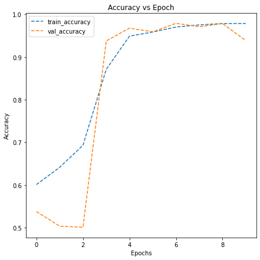

```python
# plotting the accuracies
plot_accuracy(history5)
```

**Plotting the classification report and confusion matrix**

```python
#check accuracy against test data
accuracy = model5.evaluate(gfx2, y_test, verbose=1)
print('\n', 'Test_Accuracy:-', accuracy[1])
```

```
 Test_Accuracy:- 0.930250346660614
```

```
              precision    recall  f1-score   support

           0       0.88      1.00      0.93      2535
           1       1.00      0.87      0.93      2698

    accuracy                           0.93      5233
   macro avg       0.94      0.93      0.93      5233
weighted avg       0.94      0.93      0.93      5233
```

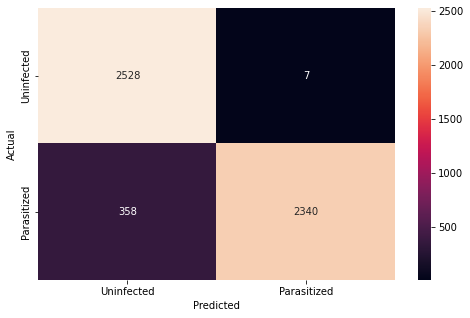

```python
from sklearn.metrics import classification_report
from sklearn.metrics import confusion_matrix

pred = model5.predict(gfx2)
pred = np.argmax(pred,axis = 1)
y_true = np.argmax(y_test,axis = 1)

#Printing the classification report
print(classification_report(y_true,pred))

#Plotting the heatmap using confusion matrix
cm = confusion_matrix(y_true,pred)
plt.figure(figsize=(8,5))
sns.heatmap(cm, annot=True,  fmt='.0f', xticklabels=['Uninfected', 'Parasitized'], yticklabels=['Uninfected', 'Parasitized'])
plt.ylabel('Actual')
plt.xlabel('Predicted')
plt.show()
```

**Observations:**

- It appears the model using the augmented HSV images does not perform as well and may be overfitting as the training data performed better than the validation data.
- Use of HSV augmentation does not perform as well as the best CNN model using the original images.
- There were far too many false negatives, and the recall of parasitized dropped to 87%.
- There does not appear to be any advantage of using HSV in this case.

# **Model 6: Data Augmentation with ImageDataGenerator**

```python
#Clearing backend
from tensorflow.keras import backend
backend.clear_session()
#Fixing the seed for random number generators
np.random.seed(42)
import random
random.seed(42)
tf.random.set_seed(42)
```

```python
from keras.preprocessing.image import ImageDataGenerator
from keras import optimizers

train_datagen = ImageDataGenerator(rescale = 1/255.,
                                  horizontal_flip = True,
                                  width_shift_range = 0.2,
                                  height_shift_range = 0.2,
                                  fill_mode = 'nearest',
                                  zoom_range = 0.3,
                                  rotation_range = 30)
val_datagen = ImageDataGenerator(rescale = 1/255.)

train_generator = train_datagen.flow(x_train, y_train, batch_size = 32, shuffle = False)
val_generator = val_datagen.flow(x_test, y_test, batch_size = 32, shuffle = False)
```

```python
#calling the best performing CNN model
model6 = CNNbuild4(height = height, width = width, classes = classes, channels = channels)
```

```python
experiment_name = "best+Augm"
logdir = os.path.join(base_logdir, experiment_name)
tensorboard_callback = tf.keras.callbacks.TensorBoard(logdir, histogram_freq=1)
```

```python
#compile the model
#optim = tf.keras.optimizers.Adam(lr = 0.001, decay = 0.001 / 32)
#model6.compile(loss = 'binary_crossentropy', optimizer = optim, metrics = ['accuracy'])
model6.compile(optimizer='adam', loss='binary_crossentropy', metrics=['accuracy'])
```

```python
#using callbacks
callbacks = [EarlyStopping(monitor='val_loss', patience=2),
             ModelCheckpoint('.mdl_wts.hdf5', monitor='val_loss', save_best_only=True), tensorboard_callback]
```

```python
#Fit the model with min batch size as 32 can tune batch size to some factor of 2^power ]
history6 = model6.fit_generator(train_generator, steps_per_epoch = len(x_train) // 64, epochs = 20)
```

```python
accuracy = model6.evaluate(val_generator, verbose=1)
print('\n', 'Test_Accuracy:-', accuracy[1])
```

```
 Test_Accuracy:- 0.9828014373779297
```

```python
predict = model6.evaluate_generator(val_generator, steps = 5)
```

```python
print(f'LOSS ON TEST DATA AFTER DATA AUGMENTATION : {predict[0]}')
print(f'ACCURACY ON TEST DATA AFTER DATA AUGMENTATION : {predict[1]}')
```

```
LOSS ON TEST DATA AFTER DATA AUGMENTATION : 0.252611368894577
ACCURACY ON TEST DATA AFTER DATA AUGMENTATION : 0.9937499761581421
```

**Plotting the training and validation**

```python
# function to plot train and validation accuracy
def plot_accuracy(history6):
    N = len(history6.history["accuracy"])
    plt.figure(figsize=(7,7))
    plt.plot(np.arange(0, N), history6.history["accuracy"], label="train_accuracy", ls='--')
    plt.plot(np.arange(0, N), history6.history["loss"], label="train_loss", ls='--')
    plt.title("Accuracy vs Epoch")
    plt.xlabel("Epochs")
    plt.ylabel("Accuracy")
    plt.legend(loc="upper left")
```

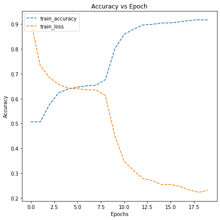

```python
# plotting the accuracies
plot_accuracy(history6)
```

**Plotting the confusion matrix and classification report**

```
              precision    recall  f1-score   support

           0       0.98      0.99      0.98      2535
           1       0.99      0.98      0.98      2698

    accuracy                           0.98      5233
   macro avg       0.98      0.98      0.98      5233
weighted avg       0.98      0.98      0.98      5233
```

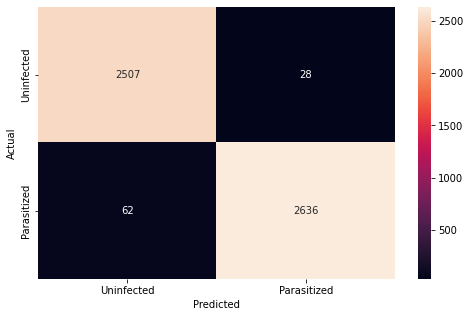

```python
from sklearn.metrics import classification_report
from sklearn.metrics import confusion_matrix

pred = model6.predict(val_generator)
pred = np.argmax(pred,axis = 1)
y_true = np.argmax(y_test,axis = 1)

#Printing the classification report
print(classification_report(y_true,pred))

#Plotting the heatmap using confusion matrix
cm = confusion_matrix(y_true,pred)
plt.figure(figsize=(8,5))
sns.heatmap(cm, annot=True,  fmt='.0f', xticklabels=['Uninfected', 'Parasitized'], yticklabels=['Uninfected', 'Parasitized'])
plt.ylabel('Actual')
plt.xlabel('Predicted')
plt.show()
```

**Observations:**

- Data augmentation through ImageDataGenerator performed extremely well.
- There will still more false negative and slighly lest performarnce as compated to the best CNN model (Model 4).
- In addition, it took considerably more time to fit the model (3 min) versus 1 min, and may be less computationally efficient.

**Now let us try to use a pretrained model like VGG16 and check how it performs on our data.**

# **Model 7: Pre-trained model (VGG16)**

```python
#Clearing backend
from tensorflow.keras import backend
backend.clear_session()
#Fixing the seed for random number generators
np.random.seed(42)
import random
random.seed(42)
tf.random.set_seed(42)
```

```python
train_labels_squeezed = np.array([np.argmax(item==1) for item in y_train])
train_labels_squeezed = train_labels_squeezed.reshape(-1,1)
train_labels_squeezed.shape
```

```
(20928, 1)
```

```python
from tensorflow.keras.applications.vgg16 import VGG16
from tensorflow.keras import Model
from tensorflow.keras.initializers import RandomNormal, Constant



vgg = VGG16(include_top=False, weights='imagenet', input_shape=(64, 64, 3))
chanDim = -1
if K.image_data_format() == 'channels_first':
        inputShape = (3, 64, 64)
vgg.summary()
```

```
Downloading data from https://storage.googleapis.com/tensorflow/keras-applications/vgg16/vgg16_weights_tf_dim_ordering_tf_kernels_notop.h5
Model: "vgg16"
_________________________________________________________________
 Layer (type)                Output Shape              Param #
=================================================================
 input_1 (InputLayer)        [(None, 64, 64, 3)]       0

 block1_conv1 (Conv2D)       (None, 64, 64, 64)        1792

 block1_conv2 (Conv2D)       (None, 64, 64, 64)        36928

 block1_pool (MaxPooling2D)  (None, 32, 32, 64)        0

 block2_conv1 (Conv2D)       (None, 32, 32, 128)       73856

 block2_conv2 (Conv2D)       (None, 32, 32, 128)       147584

 block2_pool (MaxPooling2D)  (None, 16, 16, 128)       0

 block3_conv1 (Conv2D)       (None, 16, 16, 256)       295168

 block3_conv2 (Conv2D)       (None, 16, 16, 256)       590080

 block3_conv3 (Conv2D)       (None, 16, 16, 256)       590080

 block3_pool (MaxPooling2D)  (None, 8, 8, 256)         0

 block4_conv1 (Conv2D)       (None, 8, 8, 512)         1180160

 block4_conv2 (Conv2D)       (None, 8, 8, 512)         2359808

 block4_conv3 (Conv2D)       (None, 8, 8, 512)         2359808

 block4_pool (MaxPooling2D)  (None, 4, 4, 512)         0

 block5_conv1 (Conv2D)       (None, 4, 4, 512)         2359808

 block5_conv2 (Conv2D)       (None, 4, 4, 512)         2359808

 block5_conv3 (Conv2D)       (None, 4, 4, 512)         2359808

 block5_pool (MaxPooling2D)  (None, 2, 2, 512)         0

=================================================================
Total params: 14,714,688
Trainable params: 14,714,688
Non-trainable params: 0
_________________________________________________________________
```

```python
transfer_layer = vgg.get_layer('block5_pool')
vgg.trainable=False

# Add classification layers on top of it

x = Flatten()(transfer_layer.output) #Flatten the output from the 3rd block of the VGG16 model
x = Dense(256, activation='relu')(x)
x = Dense(128, activation='relu')(x)
x = Dropout(0.3)(x)
x = Dense(64, activation='relu')(x)
x = BatchNormalization(momentum=0.95, epsilon=0.005,beta_initializer=RandomNormal(mean=0.0, stddev=0.05), gamma_initializer=Constant(value=0.9))(x)
pred = Dense(1, activation='sigmoid')(x)

model7 = Model(vgg.input, pred) #Initializing the model
```

```python
experiment_name = "VGG16"
logdir = os.path.join(base_logdir, experiment_name)
tensorboard_callback = tf.keras.callbacks.TensorBoard(logdir, histogram_freq=1)
```

#### **Compiling the model**

```python
 #compile the model
model7.compile(optimizer='Adam', loss='binary_crossentropy', metrics=['accuracy'])
#optim = tf.keras.optimizers.Adamax(lr = 0.0001)#, decay = 0.001 / 64)
model7.compile(loss = 'binary_crossentropy', optimizer = 'Adam', metrics = ['accuracy'])
```

**using callbacks**

```python
#using callbacks
callbacks = [EarlyStopping(monitor='val_loss', patience=3),
             ModelCheckpoint('.mdl_wts.hdf5', monitor='val_loss', save_best_only=True), tensorboard_callback]
```

**Fit and Train the model**

```python
#Fitting the model and running the model for 10 epochs
history7 = model7.fit(x_train, train_labels_squeezed, epochs=20, callbacks=callbacks, batch_size=32, validation_split=0.2, verbose=1)
```

**Plot the train and validation accuracy**

```python
# function to plot train and validation accuracy
def plot_accuracy(history7):
    N = len(history7.history["accuracy"])
    plt.figure(figsize=(7,7))
    plt.plot(np.arange(0, N), history7.history["accuracy"], label="train_accuracy", ls='--')
    plt.plot(np.arange(0, N), history7.history["val_accuracy"], label="VAl_accuracy", ls='--')
    plt.title("Accuracy vs Epoch")
    plt.xlabel("Epochs")
    plt.ylabel("Accuracy")
    plt.legend(loc="upper left")
```

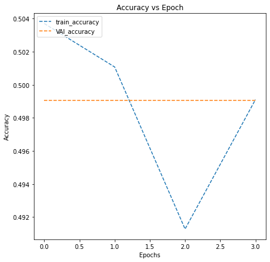

```python
# plotting the accuracies
plot_accuracy(history7)
```

#### **Evaluating the model**

```python
test_labels_squeezed = np.array([np.argmax(item==1) for item in y_test])
test_labels_squeezed = test_labels_squeezed.reshape(-1,1)
test_labels_squeezed.shape
```

```
(5233, 1)
```

```python
# Evaluating the model on test data
accuracy = model7.evaluate(x_test, test_labels_squeezed, verbose=1)
print('\n', 'Test_Accuracy:-', accuracy[1])
```

```
 Test_Accuracy:- 0.5155742168426514
```

**Plotting the classification report and confusion matrix**

```
              precision    recall  f1-score   support

           0       0.48      1.00      0.65      2535
           1       0.00      0.00      0.00      2698

    accuracy                           0.48      5233
   macro avg       0.24      0.50      0.33      5233
weighted avg       0.23      0.48      0.32      5233
```

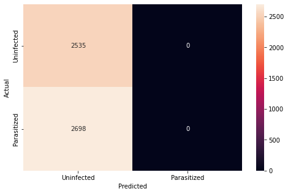

```python
from sklearn.metrics import classification_report
from sklearn.metrics import confusion_matrix

pred = model7.predict(x_test)
pred = np.argmax(pred,axis = 1)
y_true = np.argmax(y_test,axis = 1)

#Printing the classification report
print(classification_report(y_true,pred))

#Plotting the heatmap using confusion matrix
cm = confusion_matrix(y_true,pred)
plt.figure(figsize=(8,5))
sns.heatmap(cm, annot=True,  fmt='.0f', xticklabels=['Uninfected', 'Parasitized'], yticklabels=['Uninfected', 'Parasitized'])
plt.ylabel('Actual')
plt.xlabel('Predicted')
plt.show()
```

**Model 7 Observations and insights:**

- There was very poor performance and fit with VGG16.
- Class was reshaped to 1 to allow for Sigmoid and this did not allow for a fit of the data.
- The model seemed to have a great deal of difficulty fitting the validation data.
- Many iterations of this model were attempted, including making the classification layer more complex and more simple.
- All methods did not help with performance.
- Next step would be to precisely set the threshold for output using the Sigmoid classification function.

### **Executive Summary**

**Key Takeaways:**

General:

- More complex models don't always perform the best.
- Using correctly labeled data can help ensure good model development and performance on training, validation and testing.
- There is an interaction between deep layer activation function and use of batch normalization.
- It is possible to design a computationally efficient CNN model for the dection of malaria with a high degree of accuracy, precision and recall.
- An even more computationally efficint model may be possible to develop over time.
- Field deployment on smartphones appears to be possible.

Specific:

- The use of ReLU helps the model run quickly in deep layers During development sometimes learning may get stuck and LeakyReLU can help with this.
- There is an interaction between the activation function and use of BatchNormalization. These 2 hyperparameters can be tuned to allow for good performance and fast fit. -Sigmoid can be used for binary classification if the data output labes are reshaped. It would be best to set the threshold for use of the Sigmoid classifier in this instance.
- Batch size has implications for performance and how quickly a model can learn and there is a tradeoff.
- Dropout and Batch Normalization help prevent overfitting.
- Adding additional layers helps increase overall performance and learning but comes at a computational cost.

**Next Steps:**

- Attempt to reduce computational expense of Model 4 while maintaining high performance.
- Ths may be achieved by:
  - Removing layers
  - Fewer dense layer neurons
  - Larger batch sizes
- During development it will be important to ensure good performance metrics are still maintained
- Experiment with Sigmoid classification function by setting the precise threshold for values to ue for binary classification.
- Experiment with image size and other output classification methods.

**Problem and Solution Summary:**

- The key problem being solved was to develop a method for automatic detection of malaria from images of red blood cells.
- One key issue was to try to develop a model that could have good performance while using as few computational resources as possible since the rates of Malaria are highest in underdeveoped countries with few resources.
- The model goal was to have a high rate of accuracy, precision and recall (98% or greater) with very few false negatives.
- A low number of false negatives is of primary importantance since this is a medical diagnositc tool.
- Through development it was found that the use of a basic CNN model will work the best for the overall solution.
- It may be possible to further reduce the computational costs and maintain high performance.
- This will allow for easy deployment with computational efficiency and still maintain performance.

**Recommendations for Implementation:**

- A model similar in structure to Model 4 with correctly labeled images which requires no augmentation is the best model to use for further development and deployment.
- This includes:
  - 3 2D Convo Layers
    - Maxpooling
    - Dropout 0.3
    - Batch Normalization
    - ReLU for activation function
  - Dene Layer with 512 fully connected neurons
  - 0.5 Drouput
  - Softmax activation function for classification
- This model attained 99% accuracy, 99% precision, and 99% recall with only 17 false negative images identified from the test set.
- The use of this model was a basic CNN model and took only 1 minute to fit/run (w/ GPU).
- The benefits are that malaria may be diagnosed relatively quickly and easily in the field, which will allow for rapid detection of infected patinets such that treatement to be deliered quicker, leading to lower morbidity and mortality.
- Costs will mostly be in development and testing and deployment on smartphones.
- There will also have to be field testing of the final equipment and the performance compared to bench testing of the optimal model.
- The risks are that in striving for computational efficiency and depolyment on a simple platform, the model will not work as well and false negatives, which are the riskiest medicially will result.